# Daten untersuchen mit Pandas und Python für Fortgeschrittene

### Daten aus der CSV-Datei lesen

Nun benutzen wir pandas um die CSV-Datei) einzulesen. Damit das funktioniert muss vorher noch das pandas-Paket mit dem `import`-Befehl unter dem Namen `pd` verfügbar gemacht werden.

Dabei wird ein sogenannter [DataFrame](https://pandas.pydata.org/docs/reference/api/pandas.DataFrame.html) mit dem Namen `nba` erzeugt. Vereinfacht kann man sich darunter eine Tabelle mit Spalten und Zeilen vorstellen. DataFrames sind **die** zentralen Datentypen in pandas.

Mit dem Befehl `type()` kann der Datentyp eines jeden Python-Objekts ausgegeben werden.

```python
import pandas as pd
nba = pd.read_csv("nba_all_elo.csv")
type(nba)
# Expected:
# <class 'pandas.core.frame.DataFrame'>
```

```
pandas.core.frame.DataFrame
```

```python
nba.head()
```

|  | gameorder | game_id | lg_id | _iscopy | year_id | date_game | seasongame | is_playoffs | team_id | fran_id | ... | win_equiv | opp_id | opp_fran | opp_pts | opp_elo_i | opp_elo_n | game_location | game_result | forecast | notes |
| --- | --- | --- | --- | --- | --- | --- | --- | --- | --- | --- | --- | --- | --- | --- | --- | --- | --- | --- | --- | --- | --- |
| 0 | 1 | 194611010TRH | NBA | 0 | 1947 | 11/1/1946 | 1 | 0 | TRH | Huskies | ... | 40.294830 | NYK | Knicks | 68 | 1300.0000 | 1306.7233 | H | L | 0.640065 | NaN |
| 1 | 1 | 194611010TRH | NBA | 1 | 1947 | 11/1/1946 | 1 | 0 | NYK | Knicks | ... | 41.705170 | TRH | Huskies | 66 | 1300.0000 | 1293.2767 | A | W | 0.359935 | NaN |
| 2 | 2 | 194611020CHS | NBA | 0 | 1947 | 11/2/1946 | 1 | 0 | CHS | Stags | ... | 42.012257 | NYK | Knicks | 47 | 1306.7233 | 1297.0712 | H | W | 0.631101 | NaN |
| 3 | 2 | 194611020CHS | NBA | 1 | 1947 | 11/2/1946 | 2 | 0 | NYK | Knicks | ... | 40.692783 | CHS | Stags | 63 | 1300.0000 | 1309.6521 | A | L | 0.368899 | NaN |
| 4 | 3 | 194611020DTF | NBA | 0 | 1947 | 11/2/1946 | 1 | 0 | DTF | Falcons | ... | 38.864048 | WSC | Capitols | 50 | 1300.0000 | 1320.3811 | H | L | 0.640065 | NaN |

5 rows × 23 columns

# Aufgabe: Bulls vs. Pistons

vs

Im Zeitraum zwischen 1988 und 1991 herrschte ein große Rivalität zwischen den beiden Clubs.

1) Erzeugen Sie einen neuen DataFrame für die folgenden Aufgaben, der nur die benötigten Daten enthält. Ggf. können Sie gerne noch weitere spezialisierte DataFrames anlegen. 2) Wie ist die Bilanz der beiden Teams (Siege und Niederlagen in direkten Duellen) für beide Teams im gesamten Zeitraum? 3) Wie viele Siege erzielten die Bulls in den einzelnen Jahren 88-91? 4) Welches war der höchste Sieg der Bulls im Jahr 1991? 5) Wie viele Punkte pro Jahr erzielten die Bulls im Schnitt in dem genannten Zeitraum. Ermitteln Sie dasselbe für die Pistons. Visualisieren Sie. 6) Visualisieren Sie die Punktedifferenz in den Ergebnissen für alle direkten Duelle mit einem geeigneten Diagramm. 7) Welche Mannschaft hat hat die schlechteste Auswärtsbilanz im Zeitraum? Berechnen Sie den Wert basierend auf Siegen und anschließend basierend auf Punkten. Gezählt werden sollen nur Spiele die nicht in den Playoffs stattfinden.

## Lösung:

### Teilaufgabe 1

Erzeugen Sie einen neuen DataFrame für die folgenden Aufgaben, der nur die benötigten Daten enthält. Ggf. können Sie gerne noch weitere spezialisierte DataFrames anlegen.

```python
bullspistons = nba[
    ((nba["fran_id"] == "Bulls") & (nba["opp_fran"] == "Pistons") | # Heimspiel "oder" (Operator: |)
    (nba["fran_id"] == "Pistons") & (nba["opp_fran"] == "Bulls")) & # Auswärtsspiel
    (nba["year_id"] <= 1991) & # Datum bis
    (nba["year_id"] >= 1988) # Datum von
    ]
```

Das Ergebnis enthält hier zwei Zeilen pro Spiel, einen aus Bulls, einen aus Pistons Perspektive (sieht man sehr gut an der `game_id`).

```python
bullspistons.head()
```

|  | gameorder | game_id | lg_id | _iscopy | year_id | date_game | seasongame | is_playoffs | team_id | fran_id | ... | win_equiv | opp_id | opp_fran | opp_pts | opp_elo_i | opp_elo_n | game_location | game_result | forecast | notes |
| --- | --- | --- | --- | --- | --- | --- | --- | --- | --- | --- | --- | --- | --- | --- | --- | --- | --- | --- | --- | --- | --- |
| 57886 | 28944 | 198711210CHI | NBA | 1 | 1988 | 11/21/1987 | 8 | 0 | DET | Pistons | ... | 54.587196 | CHI | Bulls | 132 | 1564.2028 | 1550.8380 | A | W | 0.443759 | NaN |
| 57887 | 28944 | 198711210CHI | NBA | 0 | 1988 | 11/21/1987 | 9 | 0 | CHI | Bulls | ... | 45.919754 | DET | Pistons | 144 | 1624.9565 | 1638.3213 | H | L | 0.556241 | NaN |
| 58132 | 29067 | 198712150DET | NBA | 1 | 1988 | 12/15/1987 | 21 | 0 | CHI | Bulls | ... | 46.731087 | DET | Pistons | 127 | 1656.6526 | 1659.3357 | A | L | 0.245265 | NaN |
| 58133 | 29067 | 198712150DET | NBA | 0 | 1988 | 12/15/1987 | 19 | 0 | DET | Pistons | ... | 56.513260 | CHI | Bulls | 123 | 1561.3888 | 1558.7057 | H | W | 0.754735 | NaN |
| 58462 | 29232 | 198801160CHI | NBA | 1 | 1988 | 1/16/1988 | 31 | 0 | DET | Pistons | ... | 51.047279 | CHI | Bulls | 115 | 1527.1294 | 1540.5627 | A | L | 0.482431 | NaN |

5 rows × 23 columns

### Teilaufgabe 2

Wie ist die Bilanz der beiden Teams (Siege und Niederlagen in direkten Duellen) für beide Teams im gesamten Zeitraum?

```python
bullspistons.groupby(["fran_id", "game_result"])["game_id"].count()
```

```
fran_id  game_result
Bulls    L              28
         W              16
Pistons  L              16
         W              28
Name: game_id, dtype: int64
```

### Teilaufgabe 3

Wie viele Siege erzielten die Bulls in den einzelnen Jahren 88-91?

```python
bullspistons[((bullspistons["fran_id"] == "Bulls") & (bullspistons["game_result"] == "W"))
].groupby(["fran_id", "year_id"])["game_id"].count()
```

```
fran_id  year_id
Bulls    1988       3
         1989       2
         1990       4
         1991       7
Name: game_id, dtype: int64
```

### Teilaufgabe 4

Welches war der höchste Sieg der Bulls im Jahr 1991?

Was heißt der höchste Sieg? a) Absolut oder b) relativ im Vergleich zum Verlierer? Wenn b) muss dieser Wert erst einmal entwickelt werden.

```python
bullspistons["pts_diff"] = bullspistons["pts"]-bullspistons["opp_pts"]
```

```python
bullspistons.head()
```

|  | gameorder | game_id | lg_id | _iscopy | year_id | date_game | seasongame | is_playoffs | team_id | fran_id | ... | opp_id | opp_fran | opp_pts | opp_elo_i | opp_elo_n | game_location | game_result | forecast | notes | pts_diff |
| --- | --- | --- | --- | --- | --- | --- | --- | --- | --- | --- | --- | --- | --- | --- | --- | --- | --- | --- | --- | --- | --- |
| 57886 | 28944 | 198711210CHI | NBA | 1 | 1988 | 11/21/1987 | 8 | 0 | DET | Pistons | ... | CHI | Bulls | 132 | 1564.2028 | 1550.8380 | A | W | 0.443759 | NaN | 12 |
| 57887 | 28944 | 198711210CHI | NBA | 0 | 1988 | 11/21/1987 | 9 | 0 | CHI | Bulls | ... | DET | Pistons | 144 | 1624.9565 | 1638.3213 | H | L | 0.556241 | NaN | -12 |
| 58132 | 29067 | 198712150DET | NBA | 1 | 1988 | 12/15/1987 | 21 | 0 | CHI | Bulls | ... | DET | Pistons | 127 | 1656.6526 | 1659.3357 | A | L | 0.245265 | NaN | -4 |
| 58133 | 29067 | 198712150DET | NBA | 0 | 1988 | 12/15/1987 | 19 | 0 | DET | Pistons | ... | CHI | Bulls | 123 | 1561.3888 | 1558.7057 | H | W | 0.754735 | NaN | 4 |
| 58462 | 29232 | 198801160CHI | NBA | 1 | 1988 | 1/16/1988 | 31 | 0 | DET | Pistons | ... | CHI | Bulls | 115 | 1527.1294 | 1540.5627 | A | L | 0.482431 | NaN | -16 |

5 rows × 24 columns

Gewonnenes Spiel mit der größten Differenz:

```python
bullspistons[((bullspistons["fran_id"] == "Bulls") & (bullspistons["game_result"] == "W"))
].pts_diff.max()
```

```
21
```

Zeilenindex dieses Spiels:

```python
bullspistons[((bullspistons["fran_id"] == "Bulls") & (bullspistons["game_result"] == "W"))
].pts_diff.idxmax()
```

```
66615
```

Zugriff auf die ganze Zeile mit `loc()`

```python
bullspistons.loc[bullspistons[((bullspistons["fran_id"] == "Bulls") & (bullspistons["game_result"] == "W"))
].pts_diff.idxmax()]
```

```
gameorder               33308
game_id          199105270DET
lg_id                     NBA
_iscopy                     1
year_id                  1991
date_game           5/27/1991
seasongame                 94
is_playoffs                 1
team_id                   CHI
fran_id                 Bulls
pts                       115
elo_i               1738.3856
elo_n               1750.0942
win_equiv            65.23185
opp_id                    DET
opp_fran              Pistons
opp_pts                    94
opp_elo_i           1546.5386
opp_elo_n             1534.83
game_location               A
game_result                 W
forecast             0.629183
notes                     NaN
pts_diff                   21
Name: 66615, dtype: object
```

für Alternative a) ist das Vorgehen deutlich einfacher. Größte Punktanzahl bei gewonnen Spielen:

```python
bullspistons[((bullspistons["fran_id"] == "Bulls") & (bullspistons["game_result"] == "W"))
].pts.max()
```

```
117
```

Index dieser Zeile:

```python
bullspistons[((bullspistons["fran_id"] == "Bulls") & (bullspistons["game_result"] == "W"))
].pts.idxmax()
```

```
61973
```

Ganze Zeile mit dem höchsten absoluten Gewinn per `loc()`

```python
bullspistons.loc[bullspistons[((bullspistons["fran_id"] == "Bulls") & (bullspistons["game_result"] == "W"))
].pts.idxmax()]
```

```
gameorder               30987
game_id          198911070CHI
lg_id                     NBA
_iscopy                     0
year_id                  1990
date_game           11/7/1989
seasongame                  3
is_playoffs                 0
team_id                   CHI
fran_id                 Bulls
pts                       117
elo_i               1558.6335
elo_n               1565.5848
win_equiv           50.055714
opp_id                    DET
opp_fran              Pistons
opp_pts                   114
opp_elo_i           1721.9895
opp_elo_n           1715.0382
game_location               H
game_result                 W
forecast             0.409821
notes                     NaN
pts_diff                    3
Name: 61973, dtype: object
```

### Teilaufgabe 5

Wie viele Punkte pro Jahr erzielten die Bulls im Schnitt in dem genannten Zeitraum. Ermitteln Sie dasselbe für die Pistons. Visualisieren Sie.

```python
bullspistons[((bullspistons["fran_id"] == "Bulls"))
].groupby(["year_id"])["pts"].mean()
```

```
year_id
1988     97.000000
1989     95.500000
1990     95.000000
1991    100.333333
Name: pts, dtype: float64
```

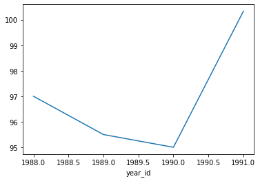

```python
bullspistons[((bullspistons["fran_id"] == "Bulls"))
].groupby(["year_id"])["pts"].mean().plot()
```

```python
bullspistons[((bullspistons["fran_id"] == "Pistons"))
].groupby(["year_id"])["pts"].mean()
```

```
year_id
1988    103.454545
1989    101.916667
1990    100.833333
1991     95.555556
Name: pts, dtype: float64
```

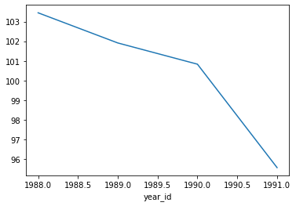

```python
bullspistons[((bullspistons["fran_id"] == "Pistons"))
].groupby(["year_id"])["pts"].mean().plot()
```

### Teilaufgabe 6

Visualisieren Sie die Punktedifferenz in den Ergebnissen für alle direkten Duelle mit einem geeigneten Diagramm.

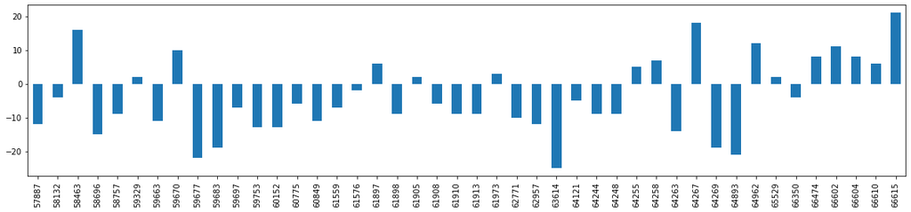

```python
bullspistons[((bullspistons["fran_id"] == "Bulls"))
].pts_diff.plot(kind="bar",figsize=(20, 4))
```

### Teilaufgabe 7

Welche Mannschaft hat hat die schlechteste Auswärtsbilanz im Zeitraum? Berechnen Sie den Wert basierend auf Siegen und anschließend basierend auf Punkten. Gezählt werden sollen nur Spiele die nicht in den Playoffs stattfinden.

```python
bullspistons[
    (bullspistons["game_location"] == "A") &
    (bullspistons["game_result"] == "W") &
    (bullspistons["is_playoffs"] == 0)
].groupby(["fran_id"])["game_id"].count()
```

```
fran_id
Bulls      2
Pistons    7
Name: game_id, dtype: int64
```

```python
bullspistons[
    (bullspistons["game_location"] == "A") &
    (bullspistons["is_playoffs"] == 0)
].groupby(["fran_id"])["pts"].sum()
```

```
fran_id
Bulls      1073
Pistons    1170
Name: pts, dtype: int64
```